# House Selling Prices

Team Zebra

```r
train <- read.csv("../Data/house-prices-advanced-regression-techniques/train.csv")
```

```r
set.seed(1939)
n <- nrow(train)
keep <- sample(1:n, 876)
mytrain <- train[keep, ]
mytest <- train[-keep, ]
mytest <- mytest %>%
  mutate(sqSalePrice = sqrt(SalePrice))
```

## MATH425

### Selecting a Model

Our selected model from the dataset containing several variables regarding homes uses ten x-variables outlined below. We also used a square-root transformation for our y-variable, which is the `SalePrice` variable of the observed homes.

$$Y_i = \beta_0 +
\beta_1X_\text{(OverallQual)i} \space +$$
$$\beta_2X_\text{as.numeric(Neighborhood == “ClearCr”)i} \space +
\beta_3X_\text{as.numeric(Neighborhood == “Somerst”)i} \space +$$

$$\beta_4X_\text{as.numeric(Neighborhood == “Timber”)i} \space +
\beta_5X_\text{as.numeric(Neighborhood == “IDOTRR”)i} \space +$$
$$\beta_6X_\text{OverallQual:as.numeric(Neighborhood == “Crawfor”)i} \space +
\beta_7X_\text{OverallQual:as.numeric(Neighborhood == “NoRidge”)i} \space +$$

$$\beta_8X_\text{OverallQual:as.numeric(Neighborhood == “NridgHt”)i} \space +
\beta_9X_\text{OverallQual:as.numeric(Neighborhood == “StoneBr”)i} \space +$$
$$\beta_{10}X_\text{OverallQual:as.numeric(Neighborhood == “Veenker”)i} \space +
\epsilon_i$$

#### Model

```r
home.mod <- lm(sqrt(SalePrice) ~ OverallQual +
as.numeric(Neighborhood == "ClearCr") +
as.numeric(Neighborhood == "Crawfor"):OverallQual +
as.numeric(Neighborhood == "NoRidge"):OverallQual +
as.numeric(Neighborhood == "NridgHt"):OverallQual +
as.numeric(Neighborhood == "Somerst") +
as.numeric(Neighborhood == "StoneBr"):OverallQual +
as.numeric(Neighborhood == "Timber") +
as.numeric(Neighborhood == "Veenker"):OverallQual +
+ as.numeric(Neighborhood == "IDOTRR")
,data=mytrain)
pander(summary(home.mod))
```

Table continues below

|  | Estimate | Std. Error | t value |
| --- | --- | --- | --- |
| **(Intercept)** | 162.6 | 8.124 | 20.02 |
| **OverallQual** | 39.74 | 1.382 | 28.76 |
| **as.numeric(Neighborhood == “ClearCr”)** | 61.24 | 10.76 | 5.69 |
| **as.numeric(Neighborhood == “Somerst”)** | 22.43 | 7.032 | 3.19 |
| **as.numeric(Neighborhood == “Timber”)** | 42.06 | 9.224 | 4.56 |
| **as.numeric(Neighborhood == “IDOTRR”)** | -40.69 | 9.117 | -4.463 |
| **OverallQual:as.numeric(Neighborhood == “Crawfor”)** | 5.61 | 1.439 | 3.898 |
| **OverallQual:as.numeric(Neighborhood == “NoRidge”)** | 12.46 | 1.238 | 10.07 |
| **OverallQual:as.numeric(Neighborhood == “NridgHt”)** | 9.558 | 0.929 | 10.29 |
| **OverallQual:as.numeric(Neighborhood == “StoneBr”)** | 6.285 | 1.346 | 4.67 |
| **OverallQual:as.numeric(Neighborhood == “Veenker”)** | 7.599 | 3.159 | 2.406 |

|  | Pr(>\|t\|) |
| --- | --- |
| **(Intercept)** | 1.462e-73 |
| **OverallQual** | 3.705e-128 |
| **as.numeric(Neighborhood == “ClearCr”)** | 1.737e-08 |
| **as.numeric(Neighborhood == “Somerst”)** | 0.001473 |
| **as.numeric(Neighborhood == “Timber”)** | 5.864e-06 |
| **as.numeric(Neighborhood == “IDOTRR”)** | 9.14e-06 |
| **OverallQual:as.numeric(Neighborhood == “Crawfor”)** | 0.0001045 |
| **OverallQual:as.numeric(Neighborhood == “NoRidge”)** | 1.273e-22 |
| **OverallQual:as.numeric(Neighborhood == “NridgHt”)** | 1.677e-23 |
| **OverallQual:as.numeric(Neighborhood == “StoneBr”)** | 3.484e-06 |
| **OverallQual:as.numeric(Neighborhood == “Veenker”)** | 0.01636 |

Fitting linear model: sqrt(SalePrice) ~ OverallQual + as.numeric(Neighborhood == “ClearCr”) + as.numeric(Neighborhood == “Crawfor”):OverallQual + as.numeric(Neighborhood == “NoRidge”):OverallQual + as.numeric(Neighborhood == “NridgHt”):OverallQual + as.numeric(Neighborhood == “Somerst”) + as.numeric(Neighborhood == “StoneBr”):OverallQual + as.numeric(Neighborhood == “Timber”) + as.numeric(Neighborhood == “Veenker”):OverallQual + +as.numeric(Neighborhood == “IDOTRR”)

| Observations | Residual Std. Error | $R^2$ | Adjusted $R^2$ |
| --- | --- | --- | --- |
| 876 | 45 | 0.7408 | 0.7378 |

#### Validation

```r
home.val <- lm(sqrt(SalePrice) ~ OverallQual + as.numeric(Neighborhood == "ClearCr") + as.numeric(Neighborhood == "Crawfor"):OverallQual + as.numeric(Neighborhood == "NoRidge"):OverallQual + as.numeric(Neighborhood == "NridgHt"):OverallQual + as.numeric(Neighborhood == "Somerst") + as.numeric(Neighborhood == "StoneBr"):OverallQual + as.numeric(Neighborhood == "Timber") + as.numeric(Neighborhood == "Veenker"):OverallQual + as.numeric(Neighborhood == "IDOTRR"),data=mytest)
#pander(summary(home.val))

yht <- predict(home.val, newdata = mytest)
Ynew <- mytest$sqSalePrice
ybar <- mean(Ynew)
SSTO <- sum((Ynew - ybar)^2)
SSE <- sum((Ynew - yht)^2)
rst <- 1 - SSE/SSTO
n <- length(Ynew)
pt <- length(coef(home.val))
rsta <- 1 - (n-1)/(n-pt)*SSE/SSTO
```

| Model | $R^2$ | Adj. $R^2$ |
| --- | --- | --- |
| Validation | 0.7251663 | 0.7203699 |

### Graphing & Interpretation of Model

The following graphics visualize our x-variables when having the square root of `SalePrice` as our response variable. This means that the following graphs show the square root of the sales price data.

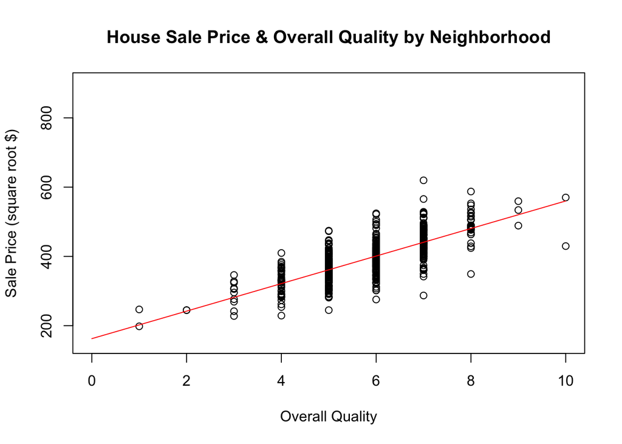

```r
b <- coef(home.mod)
# base plot all neighborhoods
plot(sqrt(SalePrice) ~ OverallQual, data = filter(mytrain, Neighborhood != "ClearCr" & Neighborhood != "Somerst" & Neighborhood != "Timber" & Neighborhood != "IDOTRR" & Neighborhood != "Crawfor" & Neighborhood != "NoRidge" & Neighborhood != "NridgHt" & Neighborhood != "StoneBr" & Neighborhood != "Veenker"), xlim = c(0,10), ylim = c(150,900),  main = "House Sale Price & Overall Quality by Neighborhood", ylab = "Sale Price (square root $)", xlab = "Overall Quality")

#OverallQual
ClearCr = 0
Somerst = 0
Timber  = 0
IDOTRR = 0
Crawfor = 0
NoRidge = 0
NridgHt = 0
StoneBr = 0
Veenker = 0

curve(b[1] + b[2]*x  + b[3]*ClearCr  + b[4]*Somerst + b[5]*Timber + b[6]*IDOTRR + b[7]*Crawfor*x + b[8]*NoRidge*x + b[9]*NridgHt*x + b[10]*StoneBr*x + b[11]*Veenker*x, add = TRUE, col = "red")
```

The above graph is a representation of the neighborhoods that are not included in our model. It appears that neighborhood and overall quality have a great impact on the sale price. For simplicity, we chose the following neighborhoods.

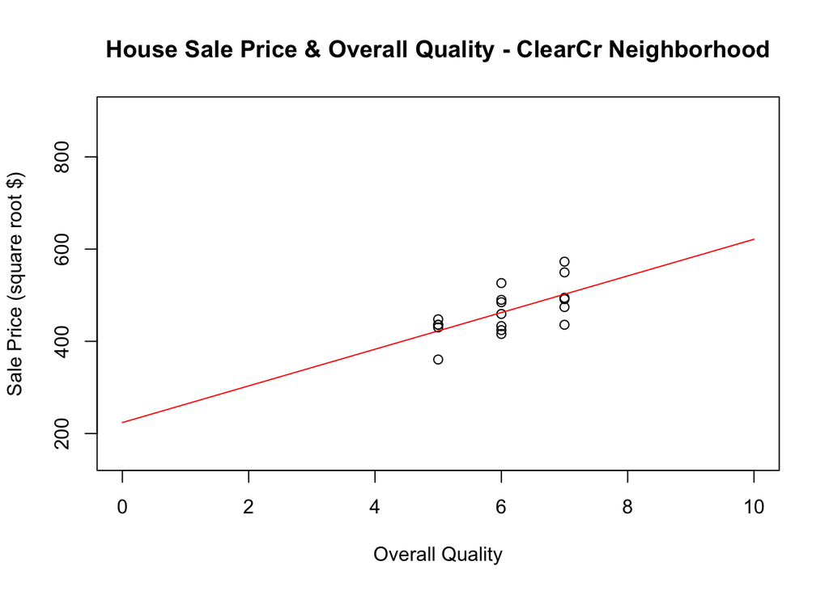

```r
plot(sqrt(SalePrice) ~ OverallQual, data = filter(mytrain, Neighborhood == "ClearCr"),
     col = as.factor(as.numeric(Neighborhood == "ClearCr") ), xlim = c(0,10), ylim = c(150,900),
     main = "House Sale Price & Overall Quality - ClearCr Neighborhood",
     ylab = "Sale Price (square root $)", xlab = "Overall Quality")

#ClearCr
ClearCr = 1
Somerst = 0
Timber  = 0
IDOTRR = 0
Crawfor = 0
NoRidge = 0
NridgHt = 0
StoneBr = 0
Veenker = 0

curve(b[1] + b[2]*x + b[3]*ClearCr  +b[4]*Somerst + b[5]*Timber + b[6]*IDOTRR + b[7]*Crawfor*x + b[8]*NoRidge*x + b[9]*NridgHt*x + b[10]*StoneBr*x + b[11]*Veenker*x, add = TRUE, col = "red")
```

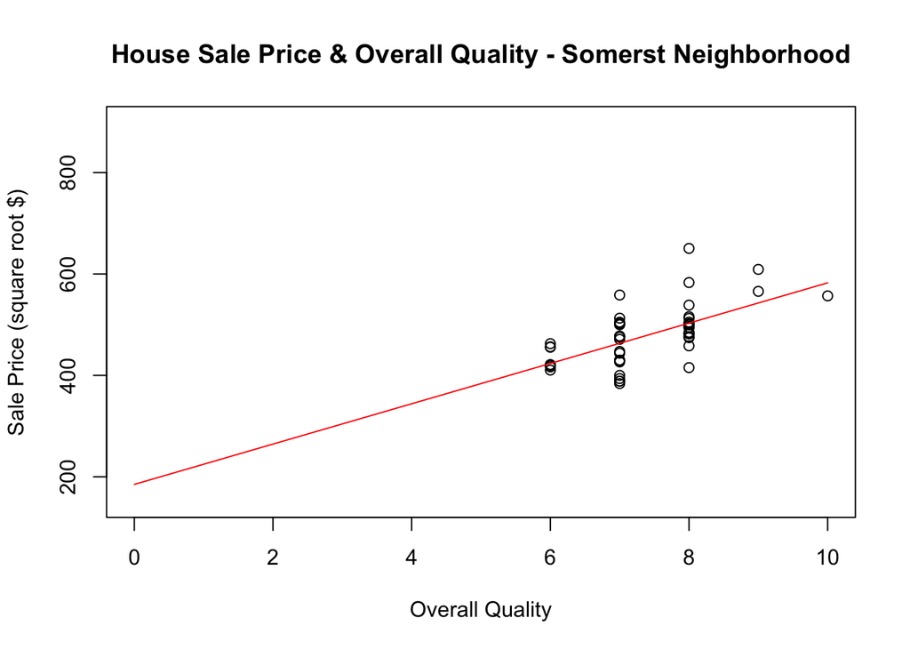

```r
plot(sqrt(SalePrice) ~ OverallQual, data = filter(mytrain, Neighborhood == "Somerst"),
     col = as.factor(as.numeric(Neighborhood == "Somerst")), xlim = c(0,10), ylim = c(150,900),
     main = "House Sale Price & Overall Quality - Somerst Neighborhood",
     ylab = "Sale Price (square root $)", xlab = "Overall Quality")

ClearCr = 0
Somerst = 1
Timber  = 0
IDOTRR = 0
Crawfor = 0
NoRidge = 0
NridgHt = 0
StoneBr = 0
Veenker = 0

curve(b[1] + b[2]*x + b[3]*ClearCr + b[4]*Somerst + b[5]*Timber + b[6]*IDOTRR + b[7]*Crawfor*x + b[8]*NoRidge*x + b[9]*NridgHt*x + b[10]*StoneBr*x + b[11]*Veenker*x, add = TRUE, col = "red")
```

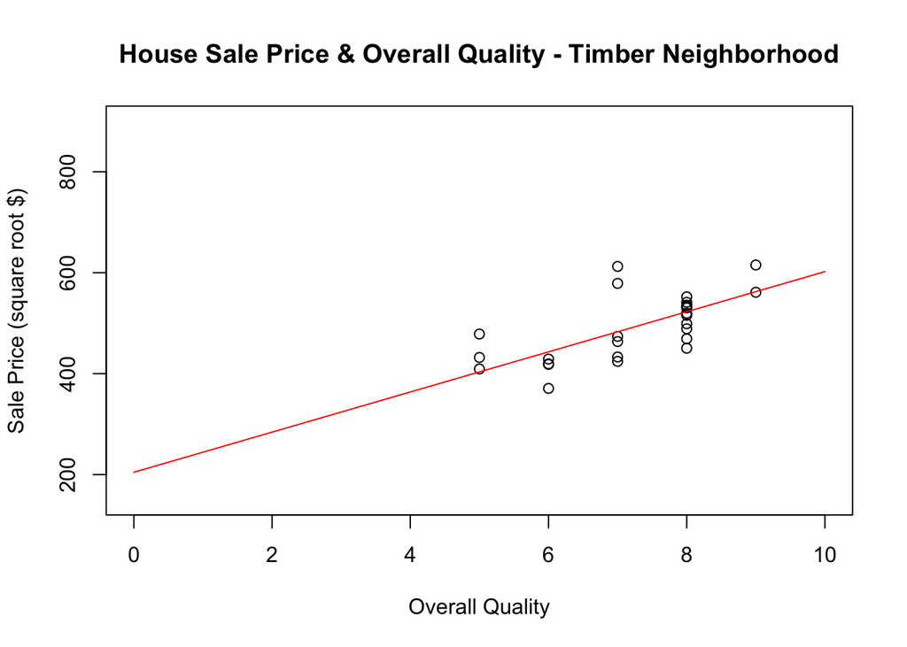

```r
plot(sqrt(SalePrice) ~ OverallQual, data = filter(mytrain, Neighborhood == "Timber"),
     col = as.factor(as.numeric(Neighborhood == "Timber")), xlim = c(0,10), ylim = c(150,900),
     main = "House Sale Price & Overall Quality - Timber Neighborhood",
     ylab = "Sale Price (square root $)", xlab = "Overall Quality")

ClearCr = 0
Somerst = 0
Timber  = 1
IDOTRR = 0
Crawfor = 0
NoRidge = 0
NridgHt = 0
StoneBr = 0
Veenker = 0

curve(b[1] + b[2]*x + b[3]*ClearCr + b[4]*Somerst + b[5]*Timber + b[6]*IDOTRR + b[7]*Crawfor*x + b[8]*NoRidge*x + b[9]*NridgHt*x + b[10]*StoneBr*x + b[11]*Veenker*x, add = TRUE, col = "red")
```

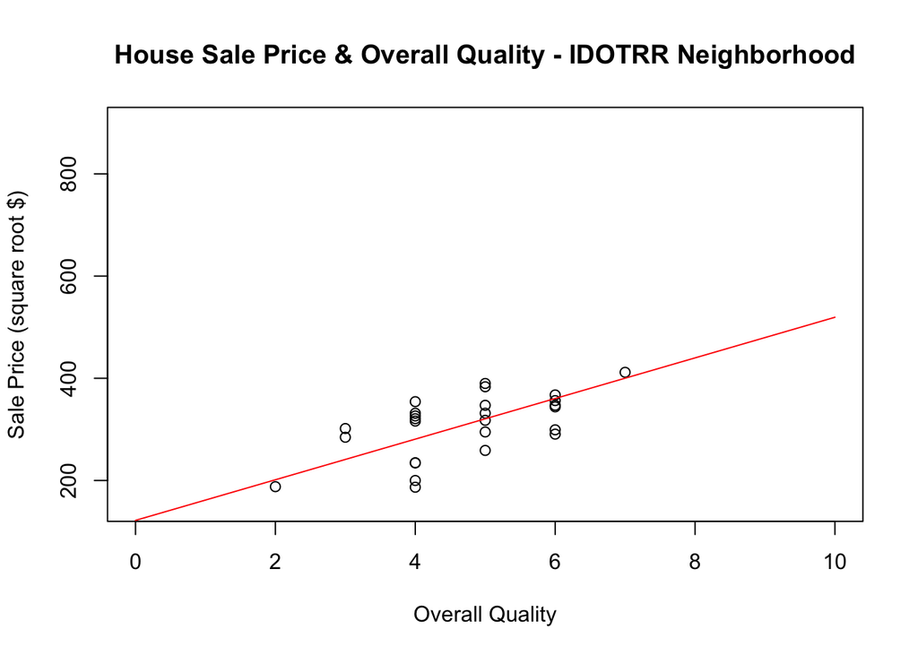

```r
plot(sqrt(SalePrice) ~ OverallQual, data = filter(mytrain, Neighborhood == "IDOTRR"),
     col = as.factor(as.numeric(Neighborhood == "IDOTRR")), xlim = c(0,10), ylim = c(150,900),
     main = "House Sale Price & Overall Quality - IDOTRR Neighborhood",
     ylab = "Sale Price (square root $)", xlab = "Overall Quality")

ClearCr = 0
Somerst = 0
Timber  = 0
IDOTRR = 1
Crawfor = 0
NoRidge = 0
NridgHt = 0
StoneBr = 0
Veenker = 0

curve(b[1] + b[2]*x + b[3]*ClearCr + b[4]*Somerst + b[5]*Timber + b[6]*IDOTRR + b[7]*Crawfor*x + b[8]*NoRidge*x + b[9]*NridgHt*x + b[10]*StoneBr*x + b[11]*Veenker*x, add = TRUE, col = "red")
```

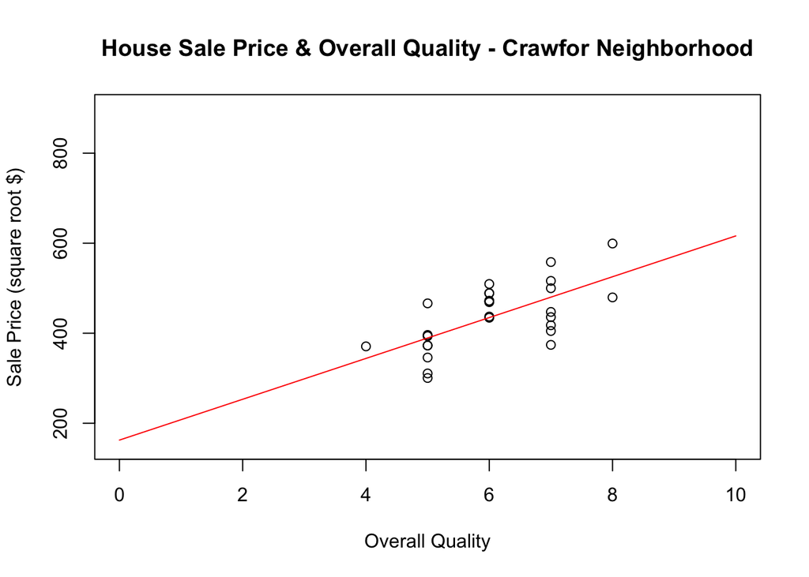

```r
plot(sqrt(SalePrice) ~ OverallQual, data = filter(mytrain, Neighborhood == "Crawfor"),
     col = as.factor(as.numeric(Neighborhood == "Crawfor") ), xlim = c(0,10), ylim = c(150,900),
     main = "House Sale Price & Overall Quality - Crawfor Neighborhood",
     ylab = "Sale Price (square root $)", xlab = "Overall Quality")

ClearCr = 0
Somerst = 0
Timber  = 0
IDOTRR = 0
Crawfor = 1
NoRidge = 0
NridgHt = 0
StoneBr = 0
Veenker = 0

curve(b[1] + b[2]*x + b[3]*ClearCr + b[4]*Somerst + b[5]*Timber + b[6]*IDOTRR + b[7]*Crawfor*x + b[8]*NoRidge*x + b[9]*NridgHt*x + b[10]*StoneBr*x + b[11]*Veenker*x, add = TRUE, col = "red")
```

For every 1 unit change in overall quality, the “Crawfor” neighborhood increases by `$5.61` square root dollars.

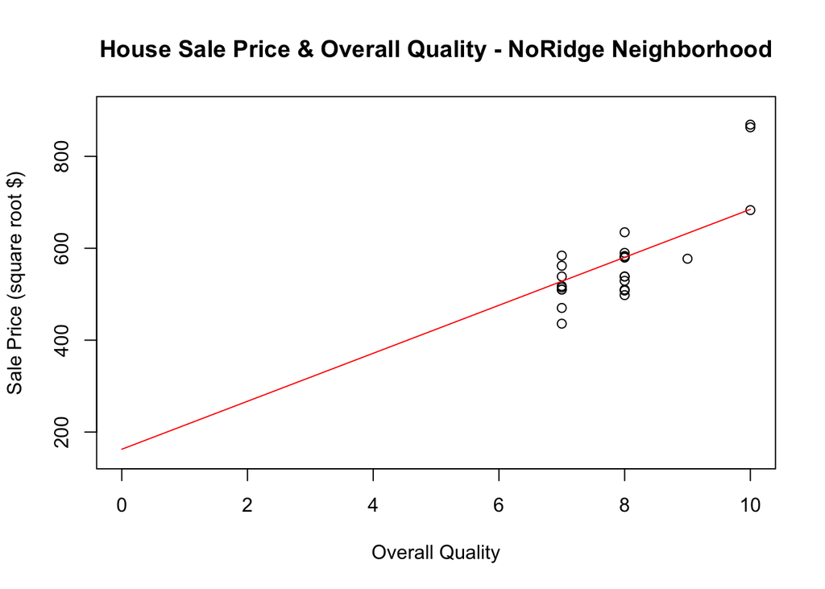

```r
plot(sqrt(SalePrice) ~ OverallQual, data = filter(mytrain, Neighborhood == "NoRidge"),
     col = as.factor(as.numeric(Neighborhood == "NoRidge") ), xlim = c(0,10), ylim = c(150,900),
     main = "House Sale Price & Overall Quality - NoRidge Neighborhood",
     ylab = "Sale Price (square root $)", xlab = "Overall Quality")

ClearCr = 0
Somerst = 0
Timber  = 0
IDOTRR = 0
Crawfor = 0
NoRidge = 1
NridgHt = 0
StoneBr = 0
Veenker = 0

curve(b[1] + b[2]*x + b[3]*ClearCr + b[4]*Somerst + b[5]*Timber + b[6]*IDOTRR + b[7]*Crawfor*x + b[8]*NoRidge*x + b[9]*NridgHt*x + b[10]*StoneBr*x + b[11]*Veenker*x, add = TRUE, col = "red")
```

For every 1 unit change in overall quality, the “NoRidge” neighborhood increases by `$12.46` square root dollars.

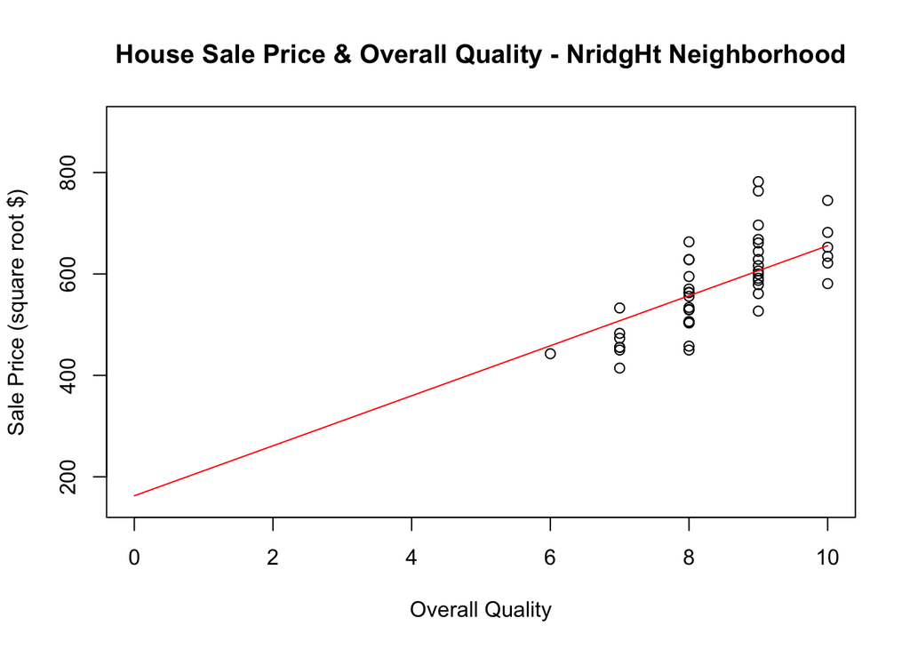

```r
plot(sqrt(SalePrice) ~ OverallQual, data = filter(mytrain, Neighborhood == "NridgHt"),
     col = as.factor(as.numeric(Neighborhood == "NridgHt") ), xlim = c(0,10), ylim = c(150,900),
     main = "House Sale Price & Overall Quality - NridgHt Neighborhood",
     ylab = "Sale Price (square root $)", xlab = "Overall Quality")

ClearCr = 0
Somerst = 0
Timber  = 0
IDOTRR = 0
Crawfor = 0
NoRidge = 0
NridgHt = 1
StoneBr = 0
Veenker = 0

curve(b[1] + b[2]*x + b[3]*ClearCr + b[4]*Somerst + b[5]*Timber + b[6]*IDOTRR + b[7]*Crawfor*x + b[8]*NoRidge*x + b[9]*NridgHt*x + b[10]*StoneBr*x + b[11]*Veenker*x, add = TRUE, col = "red")
```

For every 1 unit change in overall quality, the “NridgHt” neighborhood increases by `$9.56` square root dollars.

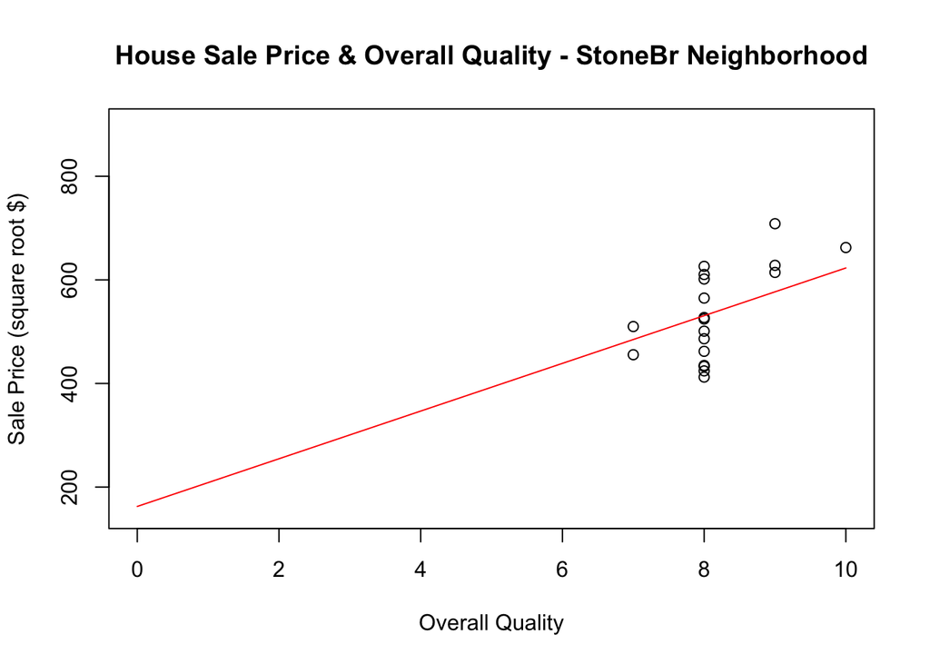

```r
plot(sqrt(SalePrice) ~ OverallQual, data = filter(mytrain, Neighborhood == "StoneBr"),
     col = as.factor(as.numeric(Neighborhood == "StoneBr") ), xlim = c(0,10), ylim = c(150,900),
     main = "House Sale Price & Overall Quality - StoneBr Neighborhood",
     ylab = "Sale Price (square root $)", xlab = "Overall Quality")

ClearCr = 0
Somerst = 0
Timber  = 0
IDOTRR = 0
Crawfor = 0
NoRidge = 0
NridgHt = 0
StoneBr = 1
Veenker = 0

curve(b[1] + b[2]*x + b[3]*ClearCr + b[4]*Somerst + b[5]*Timber + b[6]*IDOTRR + b[7]*Crawfor*x + b[8]*NoRidge*x + b[9]*NridgHt*x + b[10]*StoneBr*x + b[11]*Veenker*x, add = TRUE, col = "red")
```

For every 1 unit change in overall quality, the “StoneBr” neighborhood increases by `$6.29` square root dollars.

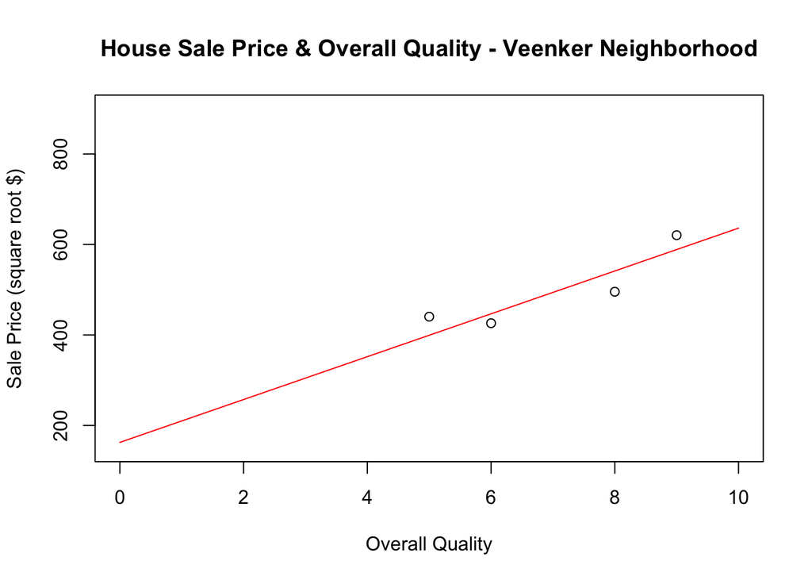

```r
plot(sqrt(SalePrice) ~ OverallQual, data = filter(mytrain, Neighborhood == "Veenker"),
     col = as.factor(as.numeric(Neighborhood == "Veenker") ), xlim = c(0,10), ylim = c(150,900),
     main = "House Sale Price & Overall Quality - Veenker Neighborhood",
     ylab = "Sale Price (square root $)", xlab = "Overall Quality")

ClearCr = 0
Somerst = 0
Timber  = 0
IDOTRR = 0
Crawfor = 0
NoRidge = 0
NridgHt = 0
StoneBr = 0
Veenker = 1

curve(b[1] + b[2]*x + b[3]*ClearCr + b[4]*Somerst + b[5]*Timber + b[6]*IDOTRR + b[7]*Crawfor*x + b[8]*NoRidge*x + b[9]*NridgHt*x + b[10]*StoneBr*x + b[11]*Veenker*x, add = TRUE, col = "red")
```

For every 1 unit change in overall quality, the “Veenker” neighborhood increases by `$7.60` square root dollars.

### Diagnostics (Skills Quiz)

```r
home.mod <- lm(sqrt(SalePrice) ~ OverallQual +
as.numeric(Neighborhood == "ClearCr") +
as.numeric(Neighborhood == "Crawfor"):OverallQual +
as.numeric(Neighborhood == "NoRidge"):OverallQual +
as.numeric(Neighborhood == "NridgHt"):OverallQual +
as.numeric(Neighborhood == "Somerst") +
as.numeric(Neighborhood == "StoneBr"):OverallQual +
as.numeric(Neighborhood == "Timber") +
as.numeric(Neighborhood == "Veenker"):OverallQual +
+ as.numeric(Neighborhood == "IDOTRR")
,data=mytrain)
pander(summary(home.mod))
```

Table continues below

|  | Estimate | Std. Error | t value |
| --- | --- | --- | --- |
| **(Intercept)** | 162.6 | 8.124 | 20.02 |
| **OverallQual** | 39.74 | 1.382 | 28.76 |
| **as.numeric(Neighborhood == “ClearCr”)** | 61.24 | 10.76 | 5.69 |
| **as.numeric(Neighborhood == “Somerst”)** | 22.43 | 7.032 | 3.19 |
| **as.numeric(Neighborhood == “Timber”)** | 42.06 | 9.224 | 4.56 |
| **as.numeric(Neighborhood == “IDOTRR”)** | -40.69 | 9.117 | -4.463 |
| **OverallQual:as.numeric(Neighborhood == “Crawfor”)** | 5.61 | 1.439 | 3.898 |
| **OverallQual:as.numeric(Neighborhood == “NoRidge”)** | 12.46 | 1.238 | 10.07 |
| **OverallQual:as.numeric(Neighborhood == “NridgHt”)** | 9.558 | 0.929 | 10.29 |
| **OverallQual:as.numeric(Neighborhood == “StoneBr”)** | 6.285 | 1.346 | 4.67 |
| **OverallQual:as.numeric(Neighborhood == “Veenker”)** | 7.599 | 3.159 | 2.406 |

|  | Pr(>\|t\|) |
| --- | --- |
| **(Intercept)** | 1.462e-73 |
| **OverallQual** | 3.705e-128 |
| **as.numeric(Neighborhood == “ClearCr”)** | 1.737e-08 |
| **as.numeric(Neighborhood == “Somerst”)** | 0.001473 |
| **as.numeric(Neighborhood == “Timber”)** | 5.864e-06 |
| **as.numeric(Neighborhood == “IDOTRR”)** | 9.14e-06 |
| **OverallQual:as.numeric(Neighborhood == “Crawfor”)** | 0.0001045 |
| **OverallQual:as.numeric(Neighborhood == “NoRidge”)** | 1.273e-22 |
| **OverallQual:as.numeric(Neighborhood == “NridgHt”)** | 1.677e-23 |
| **OverallQual:as.numeric(Neighborhood == “StoneBr”)** | 3.484e-06 |
| **OverallQual:as.numeric(Neighborhood == “Veenker”)** | 0.01636 |

Fitting linear model: sqrt(SalePrice) ~ OverallQual + as.numeric(Neighborhood == “ClearCr”) + as.numeric(Neighborhood == “Crawfor”):OverallQual + as.numeric(Neighborhood == “NoRidge”):OverallQual + as.numeric(Neighborhood == “NridgHt”):OverallQual + as.numeric(Neighborhood == “Somerst”) + as.numeric(Neighborhood == “StoneBr”):OverallQual + as.numeric(Neighborhood == “Timber”) + as.numeric(Neighborhood == “Veenker”):OverallQual + +as.numeric(Neighborhood == “IDOTRR”)

| Observations | Residual Std. Error | $R^2$ | Adjusted $R^2$ |
| --- | --- | --- | --- |
| 876 | 45 | 0.7408 | 0.7378 |

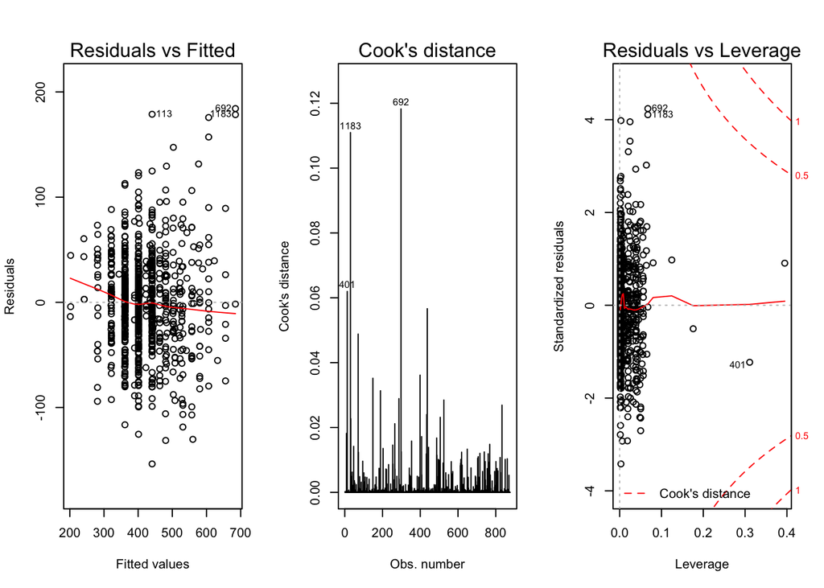

```r
par(mfrow=c(1,3))
plot(home.mod, which=c(1,4,5))
```

The most notable outliers seen here are clearly points `692` and `1183`, which is evident in all three plots. Even point `113` in the first plot and `401` on the latter two plots look questionable. To resolve this issue, we would try removing these outliers in an updated model starting first with points `692` and `1183` for sure. We would then compare the new model to our original one to see how things look.